# STA3050A - Assignment 1

Chesia Anyika

2024-05-16

# Question

The annual expenditure levels (in millions) to promote products and services for the financial services sector such as banks , insurance, investments, etc. from 2015 to 2022 are shown in the following table:

| Year | 2015 | 2016 | 2017 | 2018 | 2019 | 2020 | 2021 | 2022 |
| --- | --- | --- | --- | --- | --- | --- | --- | --- |
| **Expenditure** | 5.5 | 7.2 | 8.0 | 9.6 | 10.2 | 11.0 | 12.5 | 14.0 |

Use exponential smoothing to obtain forecasted values by taking $\alpha = 0.5, 0.7$ and $0.9$ and calculate the forecast errors. Also plot the original and smoothed values.

# Execution

## Libraries

```r
#load the necessary libraries
library(tidyverse)
```

## Create Table in Long Format

First I input the given values into vectors, and created a table in **long format** using the `data.frame()` function.

```r
#create vectors
year <- c('2015','2016','2017','2018','2019','2020','2021','2022')
expenditure <- c(5.5, 7.2, 8.0, 9.6, 10.2 ,11.0, 12.5, 14.0)

#create table
data <- data.frame(year, expenditure)

#view table
data
```

```
##   year expenditure
## 1 2015         5.5
## 2 2016         7.2
## 3 2017         8.0
## 4 2018         9.6
## 5 2019        10.2
## 6 2020        11.0
## 7 2021        12.5
## 8 2022        14.0
```

## Case 1: $\alpha = 0.5$

### Step 1: Obtain Forecast Values Using Exponential Smoothing

The formula for obtaining filtered values using exponential smoothing is:

$$y't = \alpha yt + (1- \alpha)y't - 1$$

To implement this formula in r, I first defined my alpha parameter, then I initialised an empty column in the `data` table for forecasted values, and specified the value of the first forecast value as 5.5. This is because the first forecast value ( $y't$ ) is always equals to the first value of the variable of interest ( $yt$ ), represented mathematically as: $y'1 = y1$.

```r
#define alpha parameter
alpha <- 0.5

# Initialize the first forecast value
data$Forecast.5 <- NA
data$Forecast.5[1] <- data$expenditure[1]

#view the results
data
```

```
##   year expenditure Forecast.5
## 1 2015         5.5        5.5
## 2 2016         7.2         NA
## 3 2017         8.0         NA
## 4 2018         9.6         NA
## 5 2019        10.2         NA
## 6 2020        11.0         NA
## 7 2021        12.5         NA
## 8 2022        14.0         NA
```

I then created a **for loop** that calculates the forecast values as per the formula given above, using the **value of interest in the expenditure column (** $yt$ **)**, and the **preceding value computed in the forecast column (** $y't$ **).** This yields a column of the computed forecast values with $\alpha = 0.5$.

```r
# Calculate the forecasted values using exponential smoothing
for (i in 2:nrow(data)) {
  data$Forecast.5[i] <- alpha * data$expenditure[i] + (1 - alpha) * data$Forecast.5[i-1]
}

# View the dataframe with forecasted values
data
```

```
##   year expenditure Forecast.5
## 1 2015         5.5    5.50000
## 2 2016         7.2    6.35000
## 3 2017         8.0    7.17500
## 4 2018         9.6    8.38750
## 5 2019        10.2    9.29375
## 6 2020        11.0   10.14687
## 7 2021        12.5   11.32344
## 8 2022        14.0   12.66172
```

### Step 2: Compute Forecast Error

Forecast error is computed as $yt - y't$. I computed this as follows:

```r
# Calculate the forecast error for each time period
data$Error.5 <- data$expenditure - data$Forecast.5

data
```

```
##   year expenditure Forecast.5  Error.5
## 1 2015         5.5    5.50000 0.000000
## 2 2016         7.2    6.35000 0.850000
## 3 2017         8.0    7.17500 0.825000
## 4 2018         9.6    8.38750 1.212500
## 5 2019        10.2    9.29375 0.906250
## 6 2020        11.0   10.14687 0.853125
## 7 2021        12.5   11.32344 1.176562
## 8 2022        14.0   12.66172 1.338281
```

## Case 2: $\alpha = 0.7$

### Step 1: Obtain Forecast Values Using Exponential Smoothing

```r
#define alpha parameter
alpha <- 0.7

# Initialize the first forecast value
data$Forecast.7 <- NA
data$Forecast.7[1] <- data$expenditure[1]

#view the results
data
```

```
##   year expenditure Forecast.5  Error.5 Forecast.7
## 1 2015         5.5    5.50000 0.000000        5.5
## 2 2016         7.2    6.35000 0.850000         NA
## 3 2017         8.0    7.17500 0.825000         NA
## 4 2018         9.6    8.38750 1.212500         NA
## 5 2019        10.2    9.29375 0.906250         NA
## 6 2020        11.0   10.14687 0.853125         NA
## 7 2021        12.5   11.32344 1.176562         NA
## 8 2022        14.0   12.66172 1.338281         NA
```

```r
# Calculate the forecasted values using exponential smoothing
for (i in 2:nrow(data)) {
  data$Forecast.7[i] <- alpha * data$expenditure[i] + (1 - alpha) * data$Forecast.7[i-1]
}

# View the dataframe with forecasted values
data
```

```
##   year expenditure Forecast.5  Error.5 Forecast.7
## 1 2015         5.5    5.50000 0.000000    5.50000
## 2 2016         7.2    6.35000 0.850000    6.69000
## 3 2017         8.0    7.17500 0.825000    7.60700
## 4 2018         9.6    8.38750 1.212500    9.00210
## 5 2019        10.2    9.29375 0.906250    9.84063
## 6 2020        11.0   10.14687 0.853125   10.65219
## 7 2021        12.5   11.32344 1.176562   11.94566
## 8 2022        14.0   12.66172 1.338281   13.38370
```

### Step 2: Compute Forecast Error

Forecast error is computed as $yt - y't$. I computed this as follows:

```r
# Calculate the forecast error for each time period
data$Error.7 <- data$expenditure - data$Forecast.7

data
```

```
##   year expenditure Forecast.5  Error.5 Forecast.7   Error.7
## 1 2015         5.5    5.50000 0.000000    5.50000 0.0000000
## 2 2016         7.2    6.35000 0.850000    6.69000 0.5100000
## 3 2017         8.0    7.17500 0.825000    7.60700 0.3930000
## 4 2018         9.6    8.38750 1.212500    9.00210 0.5979000
## 5 2019        10.2    9.29375 0.906250    9.84063 0.3593700
## 6 2020        11.0   10.14687 0.853125   10.65219 0.3478110
## 7 2021        12.5   11.32344 1.176562   11.94566 0.5543433
## 8 2022        14.0   12.66172 1.338281   13.38370 0.6163030
```

## Case 3: $\alpha = 0.9$

### Step 1: Obtain Forecast Values Using Exponential Smoothing

```r
#define alpha parameter
alpha <- 0.9

# Initialize the first forecast value
data$Forecast.9 <- NA
data$Forecast.9[1] <- data$expenditure[1]

#view the results
data
```

```
##   year expenditure Forecast.5  Error.5 Forecast.7   Error.7 Forecast.9
## 1 2015         5.5    5.50000 0.000000    5.50000 0.0000000        5.5
## 2 2016         7.2    6.35000 0.850000    6.69000 0.5100000         NA
## 3 2017         8.0    7.17500 0.825000    7.60700 0.3930000         NA
## 4 2018         9.6    8.38750 1.212500    9.00210 0.5979000         NA
## 5 2019        10.2    9.29375 0.906250    9.84063 0.3593700         NA
## 6 2020        11.0   10.14687 0.853125   10.65219 0.3478110         NA
## 7 2021        12.5   11.32344 1.176562   11.94566 0.5543433         NA
## 8 2022        14.0   12.66172 1.338281   13.38370 0.6163030         NA
```

```r
# Calculate the forecasted values using exponential smoothing
for (i in 2:nrow(data)) {
  data$Forecast.9[i] <- alpha * data$expenditure[i] + (1 - alpha) * data$Forecast.9[i-1]
}

# View the dataframe with forecasted values
data
```

```
##   year expenditure Forecast.5  Error.5 Forecast.7   Error.7 Forecast.9
## 1 2015         5.5    5.50000 0.000000    5.50000 0.0000000    5.50000
## 2 2016         7.2    6.35000 0.850000    6.69000 0.5100000    7.03000
## 3 2017         8.0    7.17500 0.825000    7.60700 0.3930000    7.90300
## 4 2018         9.6    8.38750 1.212500    9.00210 0.5979000    9.43030
## 5 2019        10.2    9.29375 0.906250    9.84063 0.3593700   10.12303
## 6 2020        11.0   10.14687 0.853125   10.65219 0.3478110   10.91230
## 7 2021        12.5   11.32344 1.176562   11.94566 0.5543433   12.34123
## 8 2022        14.0   12.66172 1.338281   13.38370 0.6163030   13.83412
```

### Step 2: Compute Forecast Error

Forecast error is computed as $yt - y't$. I computed this as follows:

```r
# Calculate the forecast error for each time period
data$Error.9 <- data$expenditure - data$Forecast.9

data
```

```
##   year expenditure Forecast.5  Error.5 Forecast.7   Error.7 Forecast.9
## 1 2015         5.5    5.50000 0.000000    5.50000 0.0000000    5.50000
## 2 2016         7.2    6.35000 0.850000    6.69000 0.5100000    7.03000
## 3 2017         8.0    7.17500 0.825000    7.60700 0.3930000    7.90300
## 4 2018         9.6    8.38750 1.212500    9.00210 0.5979000    9.43030
## 5 2019        10.2    9.29375 0.906250    9.84063 0.3593700   10.12303
## 6 2020        11.0   10.14687 0.853125   10.65219 0.3478110   10.91230
## 7 2021        12.5   11.32344 1.176562   11.94566 0.5543433   12.34123
## 8 2022        14.0   12.66172 1.338281   13.38370 0.6163030   13.83412
##     Error.9
## 1 0.0000000
## 2 0.1700000
## 3 0.0970000
## 4 0.1697000
## 5 0.0769700
## 6 0.0876970
## 7 0.1587697
## 8 0.1658770
```

## Compare Accuracy of Forecast Values

I then used the forecast values to compute **Mean Absolute Error** and **Mean Squared Error**, to compare the accuracy of the different forecast values given the alpha values.

```r
# Compute the Mean Absolute Error (MAE)
MAE.5 <- mean(abs(data$Error.5), na.rm = TRUE)
MAE.7 <- mean(abs(data$Error.7), na.rm = TRUE)
MAE.9 <- mean(abs(data$Error.9), na.rm = TRUE)

# Compute the Mean Squared Error (MSE)
MSE.5 <- mean(data$Error.5^2, na.rm = TRUE)
MSE.7 <- mean(data$Error.7^2, na.rm = TRUE)
MSE.9 <- mean(data$Error.9^2, na.rm = TRUE)


# View MAE and MSE
cat('\n Mean Absolute Errors: ', '\n alpha = 5: ', MAE.5, '\n alpha = 7: ', MAE.7, '\n alpha = 9: ', MAE.9, '\n Mean Squared Errors: ', '\n alpha = 5: ', MSE.5, '\n alpha = 7: ', MSE.7, '\n alpha = 9: ', MSE.9)
```

```
##
##  Mean Absolute Errors:
##  alpha = 5:  0.8952148
##  alpha = 7:  0.4223409
##  alpha = 9:  0.1157517
##  Mean Squared Errors:
##  alpha = 5:  0.9497111
##  alpha = 7:  0.2136598
##  alpha = 9:  0.01668065
```

**Interpretation**

Lower MAE and MSE values indicate a more accurate forecast value. For both MAE and MSE:

- Case 3 with $\alpha = 0.9$ has the most accurate forecast values. (MAE = 0.1158, MSE = 0.0167)
- Ccase 2 with $\alpha = 0.7$ has less accurate forecast values. (MAE = 0.4223, MSE = 0.2137)
- Case 1 with $\alpha = 0.5$ has the least accurate forecast values. (MAE = 0.8952, MSE = 0.9497)

## Plot the Original and Smoothed Values

I plotted the original and forecast values as **line graphs**, with the original values being a **solid line** and the Forecast values being **dashed lines** of **different colours dependent on the alpha value.** I did this usign the `ggplot()` and `geom_line()` functions as shown below:

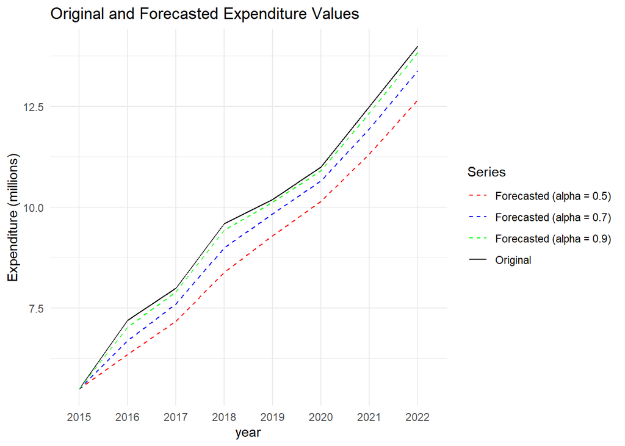

```r
# Plot original and forecasted values
ggplot(data, aes(x = year)) +
  geom_line(aes(y = expenditure, color = "Original", group = 1), linetype = "solid") +
  geom_line(aes(y = Forecast.5, color = "Forecasted (alpha = 0.5)", group = 1), linetype = "dashed") +
  geom_line(aes(y = Forecast.7, color = "Forecasted (alpha = 0.7)", group = 1), linetype = "dashed") +
  geom_line(aes(y = Forecast.9, color = "Forecasted (alpha = 0.9)", group = 1), linetype = "dashed") +
  labs(title = "Original and Forecasted Expenditure Values",
       y = "Expenditure (millions)",
       color = "Series") +
  scale_color_manual(values = c("Original" = "black",
                                 "Forecasted (alpha = 0.5)" = "red",
                                 "Forecasted (alpha = 0.7)" = "blue",
                                 "Forecasted (alpha = 0.9)" = "green")) +
  theme_minimal()
```

**Interpretation**

These observations are in line with the **observations made when comparing the accuracy of the models**. Thus, it can be concluded that the higher the alpha value, the higher the accuracy of the forecast values.